# S7f: aggiornamento del manoscritto con le analisi aggiunte

Roadmap Morris 2019, ramo morris-v4

Data di Pubblicazione

31 ottobre 2026

## In breve: il manoscritto riporta bene le analisi aggiunte, e i suoi numeri tornano?

**A cosa serviva.** Abbiamo portato nel manoscritto i risultati delle quattro analisi fatte dopo la prima stesura: la rianalisi senza nuove simulazioni, il run con i metodi aggiunti, il quarto meccanismo generatore e l’intervallo ottenuto dal test a inversione di segno. Poi il testo è passato da un revisore avversariale, che ha ricalcolato i numeri, e da un revisore di stile. Conta perché da qui il paper va alla revisione finale: ogni numero e ogni confronto devono venire dai file.

**Cosa abbiamo trovato.**

1. **La raccomandazione resta la GEE con correlazione AR(1), la correzione di Fay e Graubard e la t; il modello marginalizzato multilivello con il controllo di convergenza è un’alternativa comparabile.**
   - Su 2.376 situazioni simulate con quattro modi diversi di generare i dati, nessuna delle due strategie è mai chiaramente sopra 7,5 falsi positivi su 100.
   - La GEE dà un risultato nel 92% dei dataset, il modello marginalizzato nel 91%: la differenza è sotto la soglia di importanza, quindi sul criterio della regola sono pari.
   - La GEE va prima per due ragioni. È l’unica differenza importante: con 10 soggetti e 3 o più visite il modello marginalizzato è conservativo (2,1 falsi positivi su 100 contro 4,0). E la GEE non richiede il controllo di convergenza.
2. **Il confronto diretto fra le due strategie l’avevo letto senza soglia di importanza; rifatto con le soglie del paper, le due sono quasi ovunque pari.**
   - In media la distanza dal 5% è la stessa: 1,1 punti per entrambe.
   - Con 2 visite e almeno 15 soggetti il modello marginalizzato è più vicino al 5% di circa un punto, cioè proprio la soglia: non lo scriviamo più “preferibile”. Lì la GEE è conservativa (2,5 falsi positivi su 100).
   - Nella Figura 1 il pannello a dice “GEE” solo con 10 soggetti e 3 o più visite, e “GEE = MMM” altrove.
3. **Il revisore avversariale ha trovato i numeri giusti, ma alcune frasi dicevano più dei dati; le abbiamo corrette.**
   - “Mantengono il livello ovunque” è diventato “mai chiaramente sopra 7,5%”.
   - Il test di Wald del modello misto (il modello logistico a effetti casuali per soggetto, stimato con l’approssimazione di Laplace di lme4) è fuori taratura anche sui dati generati dal suo stesso modello, in 55 situazioni su 696, non solo quando le visite vicine sono più correlate.
   - Il test a inversione di segno, con 2-3 visite e fino a 25 soggetti, trova un effetto vero in circa 4 dataset su 100: non scriviamo più che “dice se c’è un effetto”.
   - “Chiaramente sotto 2,5%” ora si giudica con un intervallo esatto. Prima una situazione con zero falsi positivi contava come chiaramente sotto anche con pochi dataset utili. Le situazioni scendono da 136 a 116 per la GEE e da 86 a 24 per il modello marginalizzato; la scelta della regola non cambia.
4. **Le Tabelle 2, 3 e 5, ricostruite dalle singole simulazioni, coincidono con quelle stampate.**
   - Il valore diverso trovato dal revisore per il modello marginalizzato veniva da una sua selezione delle simulazioni.
   - Tutti i 2.297 numeri del manoscritto e del supplemento si rileggono dai file senza discordanze.
5. **Il testo conta 8.858 parole (200 per ogni tabella o figura), sopra le circa 8.000 della rivista.** L’abstract è di 200 parole.

**Cosa devi decidere.** Nulla.

**Comunque:**

- Quando faremo la revisione finale: il confronto con Bie e colleghi (va letta la fonte), la regola “et al.” della bibliografia secondo le istruzioni dell’editore, l’errore standard delle stime della GEE nelle applicazioni cliniche, la media delle correzioni di Mancl e DeRouen e di Kauermann e Carroll proposta da Ford e Westgate (già calcolata, da mettere o no nel supplemento), il testo di Bradley e la lunghezza.
- fewclust, nella versione registrata, sceglie ancora per primo il modello marginalizzato: l’ho provato sui dati del pacchetto e su un dataset simulato con 25 soggetti e 4 visite. Nel paper resta quindi nominato solo come il software che ha calcolato le correzioni. Quando lo aggiornerai, ti segnalo anche che negli errori stampa le prime righe della matrice del modello.
- La GEE penalizzata alla Firth non si prova. Nei limiti resta una frase che dice che non è stata valutata, insieme alla quadratura adattiva per il modello misto e ai gradi di libertà proposti da Fay e Graubard.

Non c’è nulla da decidere: se non hai dubbi, lo step è chiuso.

# Dubbi rinviati

Passano alla Revisione avversariale e ri-audit Morris (S8), dubbi ricevuti 5-10:

- confronto con Bie et al. [18] (punti 15 e 24 della revisione di stile; rilievo sulla stima fra cluster del modello marginalizzato), perche’ la fonte non e’ stata letta in questo step;
- regola “et al.” della bibliografia secondo le istruzioni SAGE/SMMR (punto 31);
- stime della GEE nella sezione 3.10 senza errore standard e senza correlazione di lavoro (punto 22);
- media di Mancl-DeRouen e Kauermann-Carroll di Ford e Westgate [14], gia’ calcolata dal revisore (esclusa dalla regola): decidere se una riga nel supplemento;
- testo di Bradley (1978), non disponibile al revisore;
- lunghezza: 8.858 parole contando 200 per tabella o figura, contro circa 8.000.

# Cancelli e previsioni

Attese pre-registrate nel commit `c19c84e` (2026-10-25), prima di costruire il registro v5 e di scrivere il testo. Valori letti dai log e dalle tabelle nel momento del render.

| attesa | atteso | intervallo | osservato | esito | spiegazione |
| --- | --- | --- | --- | --- | --- |
| GF1 integrita’ | md5 identici |  | results_full 28800 = 28800 file, identici TRUE; righe lette 95041 file, identici TRUE | superato |  |
| GF2 cifre attestate | 0 cifre fuori classe |  | GF2: 0 violations | superato |  |
| GF3a registro riletto | 0 discordanze |  | GF3a: 2297 numbers, 48 source files, 0 discordances | superato |  |
| GF3b variante kcfc | 0 differenze fuori da gee_kc |  | rows identical outside gee_kc time:trt: 0 | superato | stima uguale, SE da fewclust |
| GF3c Tabella 4 | coincide |  | 17 strategie, 0 mismatch; controlli Wald dei flag 25/25 | superato | conteggi sopra/sotto cambiati dal passaggio agli intervalli esatti di Clopper-Pearson (D-63), controllati prima della sostituzione |
| GF4 affermazioni | 0 frasi senza etichetta |  | GF4: 115 tags, 0 not ok; 0 comparative sentences without a tag | superato |  |
| GF5 completezza | render, formato, abstract <= 200 |  | manuscript/v5/MMM_v5.docx \| text runs departing: 0; manuscript/v5/MMM_v5_supplement.docx \| text runs departing: 0; format exit 0 | superato |  |
| PF1 lunghezza (parole + 200 per display) | 7.800 | 7.000-9.000 | 8.858 | confermata | sopra le circa 8.000 di SMMR: rinviato alla revisione finale |
| PF2 mediana parole per frase | 19 | 14-24 | 20 | confermata | em dashes 0, en dashes 0 |
| PF3 cambi di classe senza Kauermann-Carroll | 0 | [0, 0] | 0 (29 righe cambiano classe, tutte con Kauermann-Carroll) | confermata |  |
| PF4 Kauermann-Carroll fewclust - geesmv (punti) | < -1 | sotto -1 | -6.19 (-6.37; -6.00) | confermata | la frase ‘most anticonservative’ del v4 non c’e’ piu’ |
| Condizione citazione fewclust | fallisce (sceglie mmm) |  | fc_trial: mmm; simulated N=25 T=4 seed 20261027: mmm | fallita come atteso | fewclust citato solo come software (decisione del PI D-65) |

Cancelli (log in `reports/morris/S7f_logs/`, ultimo giro della pipeline `R/s7f/s7f_pipeline.sh` il 2026-10-27 alle 18:13):

- **GF1 superato.** `results_full/`: 28.800 file, md5 identici prima e dopo lo step e uguali alla lista di fine S7b (`results_v4/S7f/md5_results_full_{before,after}.txt`). Righe lette (`results_v4/S7d/rows`, `S7e/rows`, `S7d2/rows`, `variant_cc/S4/rows_v4.rds`): 95.041 file, md5 identici prima e dopo (digest 58b9089f2354441fc2150448b5c8362f). Gli md5 dei file sorgente del registro sono ricontrollati a ogni render da GF3a.
- **GF2 superato.** 0 cifre fuori dalle classi ammesse, nel manoscritto e nel supplemento resi in traccia.
- **GF3 superato.** (a) 2.297 voci del registro rilette da 48 file, 0 discordanze. (b) La variante `kcfc` differisce da `variant_cc` solo nelle righe `gee_kc`, con la stessa stima e l’errore standard di fewclust (`tables/V5_S7f_kcfc_gate.csv`). (c) La Tabella 4 ricostruita coincide con `tables/V4_S7e_rule.csv` su 17 strategie (usabilita’, potenza, scelta) e, per il test, con `tables/V4_S7d2_flip_rules.csv` (`tables/V5_S7f_GF3c.csv`). Dopo il passaggio agli intervalli esatti (Chiaramente sopra 7,5% e chiaramente sotto 2,5% si giudicano con l’intervallo esatto di Clopper-Pearson (D-63)) i conteggi sopra e sotto cambiano per costruzione: per questi il controllo e’ che la regola di Wald riproduca i flag salvati prima della sostituzione (25 controlli, `tables/V5_S7f_cp_gates.csv`).
- **GF4 superato.** 115 etichette di affermazione, 0 non risolte, 0 frasi comparative senza etichetta.
- **GF5 superato.** Render di manoscritto e supplemento in `.docx` e `.html` senza errori; formato Word conforme; abstract di 200 parole; ognuno dei 6 dubbi ricevuti ha un esito (sezione seguente); controllo OKF al commit.

Previsioni:

- **PF1 confermata.** 7.458 parole + 7 tabelle o figure x 200 = 8.858, dentro 7.000-9.000. E’ sopra le circa 8.000 di SMMR scritte nel piano: il taglio o la lettera all’editor passano alla revisione finale.
- **PF2 confermata.** Mediana 20,0 parole per frase (344 frasi), dentro 14-24; 0 lineette em o en; la revisione di stile non ha trovato aperture con connettivi di riempimento.
- **PF3 confermata.** 0 sotto-affermazioni senza Kauermann e Carroll nel calcolo cambiano classe (`tables/V5_S7f_PF.csv`); le 29 righe che cambiano classe (`tables/V5_S7f_claims_diff.csv`, colonna `class_change`) contengono tutte quella correzione e sono state riscritte.
- **PF4 confermata.** Kauermann e Carroll da fewclust contro geesmv, GenBinaryY, riferimento normale: -6,2 punti (intervallo per blocchi da -6,4 a -6,0), sotto -1. La frase del v4 sul metodo “most anticonservative” non c’e’ piu’.

Condizione per la citazione di fewclust: **fallita come atteso**. `auto_cluster_fit()` di fewclust 0.2.0 (commit 8538cad) sceglie `"mmm"` sui dati `fc_trial` e su un dataset simulato con 25 soggetti e 4 occasioni (`R/s7f/s7f_fewclust_condition.R`, `tables/V5_S7f_fewclust_condition.csv`). Deciso dal PI: fewclust non si cita come implementazione della raccomandazione; resta nominato come software che ha calcolato le correzioni (D-65).

# Esito dei dubbi

## Dubbi ricevuti

1. **Risultati nuovi nel testo: corretto.** Manoscritto e supplemento v5 (`manuscript/v5/`).
2. **Citazione di fewclust: deciso** (fewclust non si cita come implementazione della raccomandazione; resta nominato come software che ha calcolato le correzioni (D-65)).
3. **Dal run con i metodi aggiunti: corretto.** (a) Figura 1 e testo sulle strategie della regola, con il modello marginalizzato come alternativa comparabile (Figura 1 sulle strategie della regola; la GEE AR(1) con Fay e Graubard e t va prima, il modello marginalizzato con controllo e’ un’alternativa comparabile (D-61)); (b) Kauermann e Carroll da fewclust e nota su geesmv nel supplemento (La correzione di Kauermann e Carroll nel paper viene da fewclust; l’errore di geesmv si spiega nel supplemento (D-51)); (c) limiti riscritti con i numeri di S7d e del test secondo Nel paper il test a inversione di segno non e’ calcolabile quando il fit ridotto diverge o lo score e’ numericamente nullo (D-59); (d) fewclust nominato nella versione registrata come software.
4. **Testo della rianalisi senza nuove simulazioni: corretto** (a-f).
5. **Dal terzo meccanismo: corretto** (a-e); i conteggi “chiaramente sopra/sotto” sono ora con l’intervallo esatto; la correlazione del quarto meccanismo sugli esiti binari e’ dichiarata (0,36 fra occasioni adiacenti, 0,20 a distanza due).
6. **Dall’intervallo dal test a inversione di segno: corretto** (a, b).

## Dubbi emersi durante lo step

- **Figura 1: pannelli che contraddicevano il testo.** I pannelli b e d mostravano gli otto metodi della Tabella 2, non le due strategie della regola. Corretto (Figura 1 sulle strategie della regola; la GEE AR(1) con Fay e Graubard e t va prima, il modello marginalizzato con controllo e’ un’alternativa comparabile (D-61)).
- **Confronto diretto letto senza margini e con un errore Monte Carlo di indipendenza.** Rifatto con il bootstrap per blocchi (B = 2.000, seme 20261015) e i margini della Sez. 2.5 (`R/s7f/s7f_h2h_boot.R`, `tables/V5_S7f_h2h_boot.csv`, Tabella S31). Corretto; la presentazione e’ decisa dal PI (Figura 1 sulle strategie della regola; la GEE AR(1) con Fay e Graubard e t va prima, il modello marginalizzato con controllo e’ un’alternativa comparabile (D-61)).
- **Revisione avversariale.** 2.249 numeri riletti identici; i rilievi e il loro esito sono in `tables/V5_S7f_review_outcomes.csv` (corretti, spiegati, decisi dal PI o rinviati; nessuno aperto). Report del revisore: artifact `revisione_n2_report.md`.
- **Flag “chiaramente sotto 2,5%” con zero rifiuti.** Deciso (Chiaramente sopra 7,5% e chiaramente sotto 2,5% si giudicano con l’intervallo esatto di Clopper-Pearson (D-63)).
- **Tabelle 2, 3 e 5 non ricalcolate dal revisore (modello marginalizzato 5,65 contro 5,54).** Spiegato: ricostruite per intero dalle singole simulazioni (72 + 96 + 48 celle, `R/s7f/s7f_table{2,3,5}_recompute.R`), differenza massima sotto 1e-12; il 5,65 veniva dalla selezione delle righe del revisore; in Tabella 3 la differenza iniziale era nelle celle senza righe.
- **Estrazioni della coorte: 21,8% senza ventilati invasivi contro 26,8% atteso a 10 pazienti.** Spiegato: le 500 estrazioni sono campioni casuali semplici (`sample(ids, n)`, seme 20260807); test binomiale p = 0,012 su una sola delle cinque dimensioni, a 15, 20, 25 e 50 pazienti coerenti (`R/s7f/s7f_lus_draws_check.R`). Nel testo l’atteso e’ scritto accanto all’osservato.
- **Nuove simulazioni proposte dal revisore.** Deciso (Nessuna nuova simulazione dopo la revisione avversariale; i metodi non valutati si dichiarano fra i limiti (D-64)).
- **GEE penalizzata alla Firth.** Il PI ricordava di averla gia’ provata; nel repo e nelle sessioni non c’e’ traccia (solo il suggerimento di fewclust quando trova separazione e la proposta della revisione del 2026-08-09). Il 2026-10-31 il PI ha confermato di essersi sbagliato e che non si prova. Nei limiti resta la frase che la dichiara non valutata (Nessuna nuova simulazione dopo la revisione avversariale; i metodi non valutati si dichiarano fra i limiti (D-64)).
- **Revisione di stile.** 75 modifiche approvate dal PI applicate, piu’ una sezione 4.4 sulle applicazioni cliniche e sul quarto meccanismo; bibliografia rinumerata per prima citazione (64 citazioni, stesse 31 opere). Deciso (Revisione di stile applicata; il supplemento v5 diventa la fonte (D-62)).
- **Pannello a della Figura 1 non leggibile.** Corretto con tre etichette (Figura 1 sulle strategie della regola; la GEE AR(1) con Fay e Graubard e t va prima, il modello marginalizzato con controllo e’ un’alternativa comparabile (D-61)).
- **fewclust stampa le prime righe della matrice del modello quando un fit fallisce.** Non tocca il paper; nota per il PI, che aggiorna il pacchetto in una chat separata.

## Decisioni tecniche dell’agente

- Tabelle 2, 3 e 5 sugli otto metodi dello studio con Kauermann e Carroll da fewclust (registrata nella pre-registrazione).
- Confronto diretto delle due strategie con il bootstrap per blocchi e i margini della Sez. 2.5, come regola 6 del protocollo.
- Revisione di stile applicata; il supplemento v5 diventa la fonte (D-62).
- Riassunto «In breve» con i numeri riletti da `R/s7f/s7f_inbreve_sources.R` (`tables/V5_S7f_inbreve_sources.csv`, 28 valori su 28 uguali al testo).

# Cosa e’ girato

- Ramo `morris-v4`, pre-registrazione nel commit `c19c84e`; il commit di chiusura e’ riportato in `docs/log.md`.
- Pipeline `R/s7f/s7f_pipeline.sh` (flag con intervalli esatti, Tabella 4, bootstrap del confronto diretto, valori aggiuntivi, serie della Figura 1, tabelle cliniche, figure, specifica e registro dei numeri, controlli GF2-GF4, render, formato Word); ultimo giro il 2026-10-27, pochi minuti per giro. Variante `kcfc` della catena S4-S6 con `R/s7f/s7f_kcfc_pipeline.sh`.
- Ricostruzioni: `R/s7f/s7f_table2_recompute.R`, `s7f_table3_recompute.R`, `s7f_table5_recompute.R`, `s7f_lus_draws_check.R`, `s7f_fewclust_condition.R`, `s7f_inbreve_sources.R`.
- Software: R 4.6.1, lme4 2.0.6, fewclust 0.2.0 (commit 8538cad, `~/R/s7d_lib`), geesmv, geepack, clubSandwich, MMLB (versioni in `results_v4/S7f/sessionInfo.txt`).
- Integrita’: md5 in `results_v4/S7f/md5_*_{before,after}.txt` (`R/s7f/s7f_md5.sh`).
- Revisioni: revisore avversariale (artifact `revisione_n2_report.md`, `revisione_n2_rilievi.csv`, script `~/MMM_rev2_v5/rev2_v5_recompute.R`) e revisore di stile (75 modifiche, punti F1-F33).

# Appendice

## Figura 1 del manoscritto

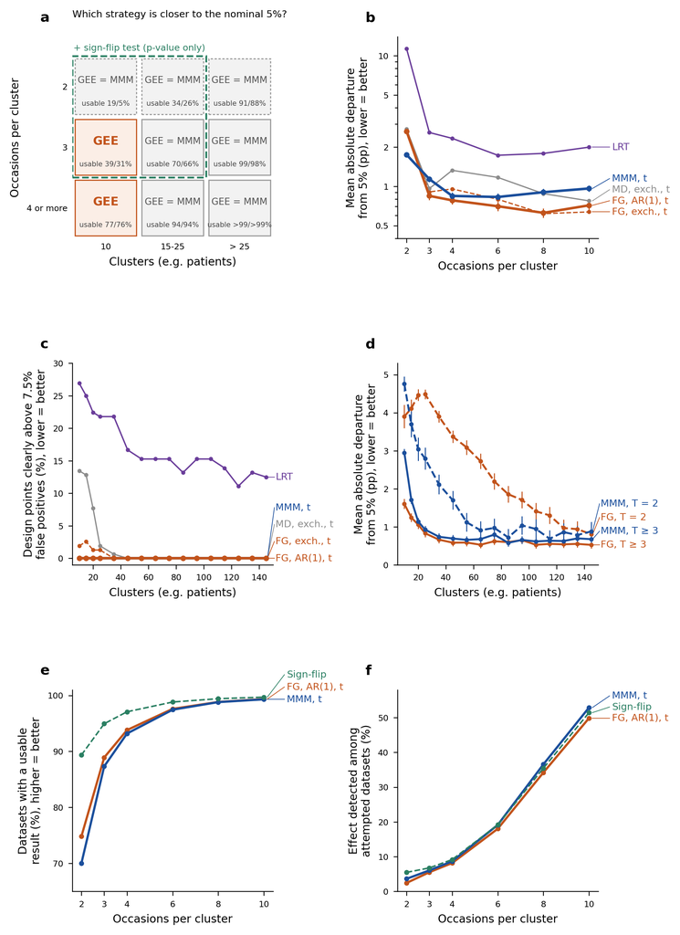

Figura 1 v5

Cosa guardare: nel pannello a, “GEE” solo nelle due caselle con 10 cluster e 3 o piu’ occasioni; nei pannelli b e d le due strategie della regola si sovrappongono quasi ovunque.

## Le due strategie della regola (Tabella 4, intervalli esatti)

| strategy | n_dp | hi_all | lo_all | lo_N10 | pu | upow | pu_small | chosen |
| --- | --- | --- | --- | --- | --- | --- | --- | --- |
| gee_ar1_fg | 2376 | 0 | 116 | 12 | 92.12 | 19.36 | 45.94 | TRUE |
| mmm_cc | 2376 | 0 | 24 | 18 | 90.89 | 20.8 | 39.16 | FALSE |
| flip | 2376 | 0 | 0 | 0 | 96.51 | 20.91 | 72.27 | FALSE |

## Confronto diretto per regione (bootstrap per blocchi, B = 2.000)

| region | n_dp | q | est | mcse | lo | hi | margin | class |
| --- | --- | --- | --- | --- | --- | --- | --- | --- |
| all | 2376 | mad_gee_minus_mmm | -0.01421 | 0.01444 | -0.0431 | 0.01467 | 1 | similar |
| all | 2376 | pu_gee_minus_mmm | 1.225 | 0.008886 | 1.208 | 1.243 | 2.5 | similar |
| all | 2376 | upow_mmm_minus_gee | 1.437 | 0.01393 | 1.409 | 1.464 | 2 | similar |
| T2 | 402 | mad_gee_minus_mmm | 0.8942 | 0.04013 | 0.814 | 0.9745 | 1 | similar |
| T2 | 402 | pu_gee_minus_mmm | 4.806 | 0.03695 | 4.733 | 4.88 | 2.5 | different |
| T2 | 402 | upow_mmm_minus_gee | 1.191 | 0.02208 | 1.146 | 1.235 | 2 | similar |
| T3p | 1974 | mad_gee_minus_mmm | -0.1992 | 0.01528 | -0.2298 | -0.1687 | 1 | similar |
| T3p | 1974 | pu_gee_minus_mmm | 0.496 | 0.007133 | 0.4818 | 0.5103 | 2.5 | similar |
| T3p | 1974 | upow_mmm_minus_gee | 1.487 | 0.01622 | 1.454 | 1.519 | 2 | similar |
| N10_T3p | 129 | mad_gee_minus_mmm | -1.346 | 0.08062 | -1.507 | -1.185 | 1 | GEE |
| N10_T3p | 129 | pu_gee_minus_mmm | 2.694 | 0.06236 | 2.569 | 2.819 | 2.5 | different |
| N10_T3p | 129 | upow_mmm_minus_gee | -0.4551 | 0.06028 | -0.5757 | -0.3345 | 2 | similar |
| N15p_T2 | 375 | mad_gee_minus_mmm | 1.02 | 0.0407 | 0.9386 | 1.101 | 1 | about the margin |
| N15p_T2 | 375 | pu_gee_minus_mmm | 4.163 | 0.03575 | 4.092 | 4.235 | 2.5 | different |
| N15p_T2 | 375 | upow_mmm_minus_gee | 1.291 | 0.02363 | 1.244 | 1.338 | 2 | similar |
| N15p_T3p | 1845 | mad_gee_minus_mmm | -0.119 | 0.01519 | -0.1494 | -0.08866 | 1 | similar |
| N15p_T3p | 1845 | pu_gee_minus_mmm | 0.3424 | 0.006059 | 0.3303 | 0.3545 | 2.5 | similar |
| N15p_T3p | 1845 | upow_mmm_minus_gee | 1.622 | 0.01693 | 1.589 | 1.656 | 2 | similar |
| small | 216 | mad_gee_minus_mmm | -0.02451 | 0.06778 | -0.1601 | 0.111 | 1 | similar |
| small | 216 | pu_gee_minus_mmm | 6.769 | 0.06285 | 6.644 | 6.895 | 2.5 | different |
| small | 216 | upow_mmm_minus_gee | -0.02659 | 0.03094 | -0.08847 | 0.03529 | 2 | similar |
| map\|10\|2 | 27 | mad_gee_minus_mmm | -0.8519 | 0.1858 | -1.223 | -0.4803 | 1 | about the margin |
| map\|10\|2 | 27 | pu_gee_minus_mmm | 13.74 | 0.226 | 13.29 | 14.19 | 2.5 | different |
| map\|10\|2 | 27 | upow_mmm_minus_gee | -0.2043 | 0.02968 | -0.2637 | -0.145 | 2 | similar |
| map\|10\|3 | 27 | mad_gee_minus_mmm | -1.822 | 0.2126 | -2.247 | -1.396 | 1 | GEE |
| map\|10\|3 | 27 | pu_gee_minus_mmm | 7.572 | 0.1854 | 7.201 | 7.943 | 2.5 | different |
| map\|10\|3 | 27 | upow_mmm_minus_gee | -0.7191 | 0.08204 | -0.8832 | -0.5551 | 2 | similar |
| map\|10\|4+ | 102 | mad_gee_minus_mmm | -1.22 | 0.08316 | -1.386 | -1.054 | 1 | GEE |
| map\|10\|4+ | 102 | pu_gee_minus_mmm | 1.403 | 0.06136 | 1.28 | 1.525 | 2.5 | similar |
| map\|10\|4+ | 102 | upow_mmm_minus_gee | -0.3852 | 0.07316 | -0.5315 | -0.2389 | 2 | similar |
| map\|15-25\|2 | 81 | mad_gee_minus_mmm | 1.176 | 0.1033 | 0.9695 | 1.383 | 1 | about the margin |
| map\|15-25\|2 | 81 | pu_gee_minus_mmm | 7.271 | 0.1016 | 7.068 | 7.475 | 2.5 | different |
| map\|15-25\|2 | 81 | upow_mmm_minus_gee | 0.5235 | 0.03068 | 0.4622 | 0.5849 | 2 | similar |
| map\|15-25\|3 | 81 | mad_gee_minus_mmm | -0.3504 | 0.1065 | -0.5634 | -0.1373 | 1 | similar |
| map\|15-25\|3 | 81 | pu_gee_minus_mmm | 3.676 | 0.08279 | 3.511 | 3.842 | 2.5 | different |
| map\|15-25\|3 | 81 | upow_mmm_minus_gee | -0.2866 | 0.06902 | -0.4247 | -0.1486 | 2 | similar |
| map\|15-25\|4+ | 306 | mad_gee_minus_mmm | -0.1804 | 0.04401 | -0.2684 | -0.09234 | 1 | similar |
| map\|15-25\|4+ | 306 | pu_gee_minus_mmm | 0.4395 | 0.02365 | 0.3922 | 0.4868 | 2.5 | similar |
| map\|15-25\|4+ | 306 | upow_mmm_minus_gee | 1.4 | 0.05072 | 1.299 | 1.501 | 2 | similar |
| map\|>25\|2 | 294 | mad_gee_minus_mmm | 0.9769 | 0.04298 | 0.891 | 1.063 | 1 | about the margin |
| map\|>25\|2 | 294 | pu_gee_minus_mmm | 3.307 | 0.0362 | 3.234 | 3.379 | 2.5 | different |
| map\|>25\|2 | 294 | upow_mmm_minus_gee | 1.502 | 0.02914 | 1.444 | 1.561 | 2 | similar |
| map\|>25\|3 | 294 | mad_gee_minus_mmm | -0.1342 | 0.03779 | -0.2098 | -0.05863 | 1 | similar |
| map\|>25\|3 | 294 | pu_gee_minus_mmm | 0.4571 | 0.01484 | 0.4275 | 0.4868 | 2.5 | similar |
| map\|>25\|3 | 294 | upow_mmm_minus_gee | 0.8561 | 0.03201 | 0.7921 | 0.9201 | 2 | similar |
| map\|>25\|4+ | 1164 | mad_gee_minus_mmm | -0.08299 | 0.01699 | -0.117 | -0.049 | 1 | similar |
| map\|>25\|4+ | 1164 | pu_gee_minus_mmm | 0.05584 | 0.00284 | 0.05016 | 0.06152 | 2.5 | similar |
| map\|>25\|4+ | 1164 | upow_mmm_minus_gee | 2.007 | 0.02171 | 1.964 | 2.051 | 2 | about the margin |
| Nb\|10\|3+ | 129 | mad_gee_minus_mmm | -1.346 | 0.08062 | -1.507 | -1.185 | 1 | GEE |
| Nb\|10\|3+ | 129 | pu_gee_minus_mmm | 2.694 | 0.06236 | 2.569 | 2.819 | 2.5 | different |
| Nb\|10\|3+ | 129 | upow_mmm_minus_gee | -0.4551 | 0.06028 | -0.5757 | -0.3345 | 2 | similar |
| Nb\|15-25\|3+ | 387 | mad_gee_minus_mmm | -0.2159 | 0.04244 | -0.3008 | -0.1311 | 1 | similar |
| Nb\|15-25\|3+ | 387 | pu_gee_minus_mmm | 1.117 | 0.02556 | 1.066 | 1.168 | 2.5 | similar |
| Nb\|15-25\|3+ | 387 | upow_mmm_minus_gee | 1.047 | 0.04264 | 0.9617 | 1.132 | 2 | similar |
| Nb\|>25\|3+ | 1458 | mad_gee_minus_mmm | -0.09332 | 0.01548 | -0.1243 | -0.06235 | 1 | similar |
| Nb\|>25\|3+ | 1458 | pu_gee_minus_mmm | 0.1368 | 0.003809 | 0.1291 | 0.1444 | 2.5 | similar |
| Nb\|>25\|3+ | 1458 | upow_mmm_minus_gee | 1.775 | 0.01829 | 1.739 | 1.812 | 2 | similar |

## Esito dei rilievi della revisione avversariale

| finding | topic | outcome | how |
| --- | --- | --- | --- |
| V-001 | Errore Monte Carlo del confronto diretto con approssimazione di indipendenza | corretto | Confronto rifatto con il bootstrap per blocchi dichiarato nei Metodi (R/s7f/s7f_h2h_boot.R, tables/V5_S7f_h2h_boot.csv, Tabella S31) |
| V-002 | Differenze entro i margini scritte come differenze | corretto | Usabilita’ e potenza complessive scritte come simili (margini 2,5 e 2 punti, Sez. 2.5) |
| V-003 | Shrinkage: ‘only its interval differs’ | corretto | Frase riscritta: stessa statistica sullo stesso fit, tasso di rifiuto diverso per il filtro di usabilita’ |
| V-004 | Tabella S28 con la versione del test senza regole di non calcolabilita’ | corretto | Valori dal file con le regole del test non calcolabile |
| V-005 | Segno della colonna ‘N <= 25’ nelle Tabelle S11 e S24 | corretto | Colonna rinominata ‘Normal minus t at N <= 25’, cosi’ il verso e’ dichiarato |
| V-006 | Numero stampato con 15 cifre nel supplemento | corretto | Formato arrotondato |
| V-007 | Distorsione a 10 pazienti nel trial respiratorio | corretto | ‘within two Monte Carlo standard errors of zero’ a 10 e a 50 pazienti |
| V-008 | Cifra 0.015 non giustificata dalla MCSE (coorte) | corretto | MCSE nel registro (0,0137), frase ‘within two Monte Carlo standard errors of zero’ con controllo \|bias\| < 2 MCSE |
| V-009 | 45% dei trial stepped-wedge citato di seconda mano | corretto | ‘citing an earlier review’ |
| V-010 | Limite b della correzione di Fay e Graubard non dichiarato | corretto | b = 0,75 dichiarato e controllato su fewclust e geesmv |
| V-011 | ‘kept their level at every design point’ | corretto | Ridotto a ‘mai chiaramente sopra 7,5%’ |
| V-012 | Modello misto anticonservativo ‘solo’ con dipendenza seriale | corretto | ‘more so with serial dependence’; 55 punti su 696 sul suo stesso meccanismo |
| V-013 | Modello marginalizzato ‘preferable’ con T = 2 e N >= 15 | deciso dal PI | Parita’ (D-61): differenza dell’ordine del margine |
| V-014 | GEE ‘piu’ vicina’ con T >= 3 a ogni N | corretto | Solo a 10 cluster oltre il margine; simili da 15 cluster |
| V-015 | Scelta della regola per 1,2 punti di usabilita’ | deciso dal PI | Parita’ sul criterio della regola; GEE prima per 10 cluster e assenza del controllo (D-61) |
| V-016 | Test a inversione di segno ‘can say whether there is an effect’ | corretto | Potenza 4,2% con T <= 3 e N <= 25 dichiarata |
| V-018 | Frase sulle coorti perinatali senza fonte | corretto | Frase tolta |
| V-019 | ‘Clearly below 2.5%’ con MCSE di Wald nulla a zero rifiuti | deciso dal PI | Intervalli esatti di Clopper-Pearson (D-63) |
| V-020 | Tabella 4, due strategie della regola | verificato | Identiche sui 2.376 punti |
| V-021 | Tabella 4, altre strategie GEE | verificato | Identiche |
| V-023 | Rilettura indipendente del registro | verificato | 2.249 su 2.249 identici |
| V-024 | 113 etichette di affermazione | verificato | Coerenti con la regola della Sez. 2.5 |
| V-025 | Descrizione della coorte | verificato | Ricalcolata da lurid_long.rds |
| V-026 | 22% di estrazioni senza ventilati contro 27% atteso | spiegato | Estrazioni casuali semplici; fluttuazione a N = 10 (p = 0,012), coerenti a 15-50; atteso scritto accanto all’osservato (R/s7f/s7f_lus_draws_check.R) |
| V-027 | Coorte: usabilita’, rapporti SE, distorsione | verificato | Identici |
| V-028 | Trial respiratorio: usabilita’ e rapporti SE | verificato | Identici |
| V-029 | Coerenza interna fra tabelle | verificato | Tutte le uguaglianze tornano |
| V-030 | Seme, generatore e parametri dei Metodi | verificato | Confermati nel codice |
| V-032..V-042 | Citazioni | verificato | Contenuto e metadati (CrossRef) coerenti |
| V-043 | Bradley 1978 | rinviato | Testo non disponibile al revisore; si legge nella revisione finale |
| V-044 | Trial respiratorio, N = 50 | verificato | -0,005 con MCSE 0,020 |
| V-045 | Tabelle 2, 3 e 5 (5,65 contro 5,54 per il modello marginalizzato) | spiegato | Ricostruite per intero dalle singole simulazioni: differenza massima circa 1e-13; il 5,65 veniva dalla selezione delle righe del revisore; in Tabella 3 le celle senza righe (R/s7f/s7f_table{2,3,5}_rec… |
| V-046 | Intervalli esatti per i flag | applicato | D-63 |
| V-047 | Confronto diretto con margini e bootstrap per blocchi | applicato | Sez. 3.4, Figura 1 a, Tabella S31 |
| V-048 | Potenza aggiustata per il livello | letto | Sostiene la parita’ (D-61); non entra nel testo |
| V-049 | Distanza media corretta per il rumore Monte Carlo | letto | Ordinamento invariato in ogni regione |
| V-050, V-065 | Media di Mancl-DeRouen e Kauermann-Carroll (Ford e Westgate) | rinviato | Revisione finale: decidere se una riga nel supplemento |
| V-051 | Correlazione del quarto meccanismo sugli esiti binari | corretto | Lag 1 e lag 2 sugli esiti binari dichiarati (tables/V4_S7e_dependence_profiles.csv) |
| V-052 | Identita’ AR(1) = exchangeable a T = 2 | verificato | tables/V5_S7f_T2_ar1_exch_identity.csv |
| V-053..V-058 | Nuove simulazioni proposte (quadratura adattiva, score robusto, GEE penalizzata, quadratura del MMM, gradi di liberta’ FG, rho) | deciso dal PI | Nessuna nuova simulazione; frase nei limiti (D-64) |
| V-059 | Randomizzazione semplice a N = 10 | corretto | Frase nei limiti |
| V-060 | Stima fra cluster nel modello marginalizzato (Bie et al.) | rinviato | Revisione finale, insieme al confronto con Bie et al. |
| V-061, V-062 | Parita’ e preferenza a T = 2 | deciso dal PI | D-61 |
| V-063 | Flag ‘clearly below’ | deciso dal PI | D-63 |
| V-064 | Analisi oltre le 4 ore | deciso dal PI | D-64 |

## Condizione per la citazione di fewclust

| dataset | formula | group | time | chosen | paper_rule | condition_met | fewclust_commit |
| --- | --- | --- | --- | --- | --- | --- | --- |
| fc_trial | y ~ arm * time | id | time | mmm | gee_ar1_fg_t | FALSE | 8538cad33908e4bf518e1642eca702bea867b5e5 |
| simulated N=25 T=4 seed 20261027 | y ~ arm * time | id | time | mmm | gee_ar1_fg_t | FALSE | 8538cad33908e4bf518e1642eca702bea867b5e5 |

## Da dove vengono i numeri del riassunto

Ogni valore e’ riletto da `R/s7f/s7f_inbreve_sources.R`, che fallisce se un valore differisce da quello scritto.

| sentence | file | row | value | written | ok |
| --- | --- | --- | --- | --- | --- |
| 1. nessuna delle due supera mai chiaramente 7,5% (GEE) | tables/V5_S7f_table4.csv | strategy=gee_ar1_fg, hi_all | 0 | 0 | TRUE |
| 1. nessuna delle due supera mai chiaramente 7,5% (MMM) | tables/V5_S7f_table4.csv | strategy=mmm_cc, hi_all | 0 | 0 | TRUE |
| 1. 2.376 situazioni | tables/V5_S7f_table4.csv | strategy=gee_ar1_fg, n_dp | 2376 | 2376 | TRUE |
| 1. GEE risponde nel 92% | tables/V5_S7f_table4.csv | strategy=gee_ar1_fg, pu | 92 | 92 | TRUE |
| 1. MMM risponde nel 91% | tables/V5_S7f_table4.csv | strategy=mmm_cc, pu | 91 | 91 | TRUE |
| 1. differenza di usabilita’ sotto la soglia (2,5 punti) | tables/V5_S7f_h2h_boot.csv | region=all, q=pu_gee_minus_mmm, class | similar | similar | TRUE |
| 1. a 10 cluster con 3+ occasioni: MMM 2,1 falsi positivi su 100 | tables/V5_S7f_h2h_boot.csv | region=N10_T3p, q=rate_mmm | 2.1 | 2.1 | TRUE |
| 1. a 10 cluster con 3+ occasioni: GEE 4,0 | tables/V5_S7f_h2h_boot.csv | region=N10_T3p, q=rate_gee | 4 | 4 | TRUE |
| 1. a 10 cluster con 3+ occasioni la differenza e’ oltre la soglia, a favore della GEE | tables/V5_S7f_h2h_boot.csv | region=N10_T3p, q=mad_gee_minus_mmm, class | GEE | GEE | TRUE |
| 2. distanza media dal 5%: 1,1 punti (GEE) | tables/V5_S7f_h2h_boot.csv | region=all, q=mad_gee | 1.1 | 1.1 | TRUE |
| 2. distanza media dal 5%: 1,1 punti (MMM) | tables/V5_S7f_h2h_boot.csv | region=all, q=mad_mmm | 1.1 | 1.1 | TRUE |
| 2. con 2 occasioni e almeno 15 cluster: circa un punto, a cavallo della soglia | tables/V5_S7f_h2h_boot.csv | region=N15p_T2, q=mad_gee_minus_mmm, est / class | 1 about the margin | 1 about the margin | TRUE |
| 2. li’ la GEE e’ conservativa: 2,5 falsi positivi su 100 | tables/V5_S7f_h2h_boot.csv | region=N15p_T2, q=rate_gee | 2.5 | 2.5 | TRUE |
| 2. Figura 1 a: ‘GEE’ solo a 10 cluster con 3 e con 4+ occasioni | tables/V5_S7f_h2h_boot.csv | region=map\|*, q=mad_gee_minus_mmm, class in (GEE, MMM) | map\|10\|3:GEE; map\|10\|4+:GEE | map\|10\|3:GEE; map\|10\|4+:GEE | TRUE |
| 3. modello misto sopra 7,5% sul suo stesso meccanismo: 55 situazioni | tables/V5_S7f_extra.csv | key=glmer_hi_native | 55 | 55 | TRUE |
| 3. … su 696 | tables/V5_S7f_extra.csv | key=glmer_ndp_native | 696 | 696 | TRUE |
| 3. test a inversione di segno con 2-3 visite e fino a 25 soggetti: effetto trovato in circa 4 dataset su 100 | tables/V5_S7f_extra.csv | key=flip_upow_small | 4 | 4 | TRUE |
| 3. ‘chiaramente sotto 2,5%’ prima: GEE 136 | tables/V4_S7e_rule.csv | set=all four mechanisms, strategy=gee_ar1_fg, n_lo | 136 | 136 | TRUE |
| 3. ‘chiaramente sotto 2,5%’ prima: MMM 86 | tables/V4_S7e_rule.csv | set=all four mechanisms, strategy=mmm_cc, n_lo | 86 | 86 | TRUE |
| 3. con intervalli esatti: GEE 116 | tables/V5_S7f_table4.csv | strategy=gee_ar1_fg, lo_all | 116 | 116 | TRUE |
| 3. con intervalli esatti: MMM 24 | tables/V5_S7f_table4.csv | strategy=mmm_cc, lo_all | 24 | 24 | TRUE |
| 4. Tabelle 2, 3 e 5 ricostruite coincidono (differenza massima sotto 1e-12) | tables/V5_S7f_table{2,3,5}_recompute.csv | max \|stampato - ricalcolato\| sulle celle con righe | 9.9e-14 | < 1e-12 | TRUE |
| 4. celle confrontate (72 + 96 + 48) | tables/V5_S7f_table{2,3,5}_recompute.csv | righe | 216 | 216 | TRUE |
| 4. numeri del manoscritto riletti: 2.297, nessuno discordante | reports/morris/S7f_logs/S7f_GF3a.log | riga GF3a | GF3a: 2297 numbers, 48 source files, 0 discordances | GF3a: 2297 numbers, 48 source files, 0 discordances | TRUE |
| 5. 8.858 parole | reports/morris/S7f_logs/S7f_PF1PF2.log | riga P1 | P1: words 7458 + 200 x 7 display items = 8858 | P1: words 7458 + 200 x 7 display items = 8858 | TRUE |
| 5. abstract 200 parole | reports/morris/S7f_logs/S7f_PF1PF2.log | riga abstract | abstract words 200 | abstract words 200 | TRUE |
| Comunque: fewclust registrato sceglie il modello marginalizzato (dati del pacchetto) | tables/V5_S7f_fewclust_condition.csv | dataset=fc_trial, chosen | mmm | mmm | TRUE |
| Comunque: fewclust registrato sceglie il modello marginalizzato (25 soggetti, 4 visite) | tables/V5_S7f_fewclust_condition.csv | dataset=simulated, chosen | mmm | mmm | TRUE |